# Part 1:

### 3.4.8. - Write and perform your hypothesis along with significance test comparing the funds raised by companies across NY, SF and EU events from 2013 onwards.

```python
def Event_city(x): # x is the value of Event column
    if 'NYC' in x or 'NY' in x:
        return 'NY'
    elif 'SF' in x:
        return 'SF'
    elif 'EU' in x:
        return 'EU'
    elif 'London' in x:
        return 'LO'
    else:
        return 'Other'
```

```python
eco_dropped_final_Disrupt_after_2013.insert(6, 'Event_city',eco_dropped_final_Disrupt_after_2013['Event'].apply(Event_city))
eco_dropped_final_Disrupt_after_2013.head()
```

|  | Startup | Product | Funding_in_Millions | Event | Result | OperatingState | Event_city |
| --- | --- | --- | --- | --- | --- | --- | --- |
| 1 | 3DLT | 3dlt.com | 0.63 | Disrupt NYC 2013 | Contestant | Closed | NY |
| 3 | 3Dprintler | 3dprintler.com | 1.00 | Disrupt NY 2016 | Audience choice | Operating | NY |
| 13 | Agrilyst | agrilyst.com | 1.00 | Disrupt SF 2015 | Winner | Operating | SF |
| 14 | Aiden | aiden.ai | 0.75 | Disrupt London 2016 | Contestant | Operating | LO |
| 16 | Aircall | aircall.io | 11.60 | Disrupt SF 2015 | Contestant | Operating | SF |

```python
eco_NY_details = eco_dropped_final_Disrupt_after_2013[eco_dropped_final_Disrupt_after_2013['Event_city'] == 'NY']['Funding_in_Millions'].describe()
eco_NY_details
```

```
count    71.000000
mean      3.605079
std       4.640688
min       0.020000
25%       0.510000
50%       1.600000
75%       5.900000
max      22.000000
Name: Funding_in_Millions, dtype: float64
```

```python
eco_EU_details = eco_dropped_final_Disrupt_after_2013[eco_dropped_final_Disrupt_after_2013['Event_city'] == 'EU']['Funding_in_Millions'].describe()
eco_EU_details
```

```
count    19.000000
mean      3.559732
std       4.885227
min       0.275000
25%       0.455750
50%       1.100000
75%       6.050000
max      18.200000
Name: Funding_in_Millions, dtype: float64
```

```python
eco_SF_details = eco_dropped_final_Disrupt_after_2013[eco_dropped_final_Disrupt_after_2013['Event_city'] == 'SF']['Funding_in_Millions'].describe()
eco_SF_details
```

```
count    74.000000
mean      2.962930
std       3.505991
min       0.020000
25%       0.525000
50%       1.600000
75%       3.275000
max      12.500000
Name: Funding_in_Millions, dtype: float64
```

#### HA: At least one of the mean differs

#### alpha = .05

```python
import statsmodels.api as sm
from statsmodels.formula.api import ols

mod = ols('Funding_in_Millions ~ Event_city', data = eco_dropped_final_Disrupt_after_2013).fit()
aov_table = sm.stats.anova_lm(mod, typ=2)
print(aov_table)
```

```
                 sum_sq     df         F    PR(>F)
Event_city    24.036899    3.0  0.463831  0.707883
Residual    3126.629489  181.0       NaN       NaN
```

Calculated p value is 0.707883 and it is more than our chosen level of signifance at 5%

So the statistical decision is that there is NO sufficient evidence to reject the null hypothesis at 5% level of significance.

==========================================================================================================

### 3.4.9 - Plot the distribution plot comparing the 3 city events

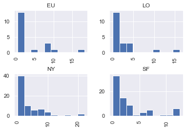

```python
eco_dropped_final_Disrupt_after_2013.hist(by = 'Event_city');
```

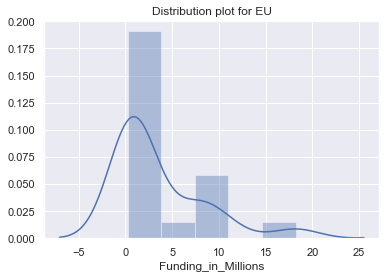

```python
sns.distplot(eco_dropped_final_Disrupt_after_2013[eco_dropped_final_Disrupt_after_2013['Event_city'] == 'EU']['Funding_in_Millions']);
plt.title('Distribution plot for EU')
```

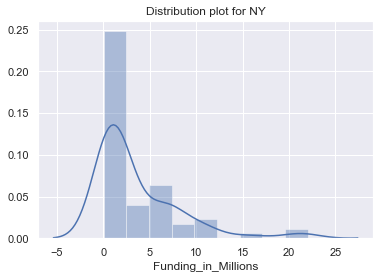

```python
sns.distplot(eco_dropped_final_Disrupt_after_2013[eco_dropped_final_Disrupt_after_2013['Event_city'] == 'NY']['Funding_in_Millions']);
plt.title('Distribution plot for NY')
```

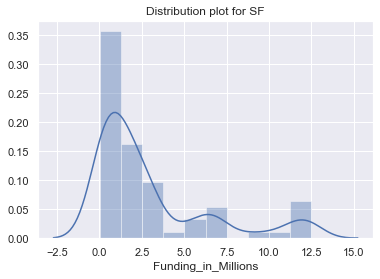

```python
sns.distplot(eco_dropped_final_Disrupt_after_2013[eco_dropped_final_Disrupt_after_2013['Event_city'] == 'SF']['Funding_in_Millions']);
plt.title('Distribution plot for SF')
```

=================================================================================================================

# 3.5 - Write your observations on improvements or suggestions on quality, quantity, variety, velocity, veracity etc. on the data points collected to perform a better data analysis.